# 0110

## Grid approximation of the posterior

This notebook will walk you through calculating an approximate posterior distribution for the unemployment rate in Newfoundland and Labrador.

Start by simulating the entire population...

```r
# Let's pretend there are 354,949 employed and 65,108 unemployed adults
pop_unemp <- sample(rep(c('E','U'),times=c(354949, 65108)))
# (the sample() function with argument just shuffles the vector)
```

Take a sample of 50 individuals.

```r
ssize <- 50
samp <- sample(pop_unemp,ssize,replace=FALSE)
# count employed and unemployed
table(samp)
```

```
samp
 E  U
43  7
```

Build a 'grid' of 11 points spanning [0,1].

```r
n_grid <- 11
grid <- seq(from=0,to=1,length.out=n_grid)
print(grid)
```

```
 [1] 0.0 0.1 0.2 0.3 0.4 0.5 0.6 0.7 0.8 0.9 1.0
```

Remember: to calculate the (proportional) posterior $Pr(p|\mathtt{ssize},\mathtt{samp})$ for a particular point on the grid (e.g. $p=0.3$), we simply calculate the *likelihood* of the data at $p=0.3$, and our *prior* probability that $p=0.3$.

Start with the prior, which for now we will just set as uniform:

```r
prior <- rep(1,times=n_grid)
print(prior)
```

```
 [1] 1 1 1 1 1 1 1 1 1 1 1
```

Now calculate the likelihood. As we saw in the slides, the likelihood in this situation is the Binomial probability mass function (PMF). R has a function `dbinom()` that calculates the binomoial PMF.

```r
# we are counting unemployment as a binomial 'success'
#print(samp)
#print(samp=='U')
n_unemp <- sum(samp=='U')
print(n_unemp)

lik <- dbinom(n_unemp,size=ssize,prob=grid)
print(cbind(grid,lik))
```

```
[1] 7
      grid          lik
 [1,]  0.0 0.000000e+00
 [2,]  0.1 1.076281e-01
 [3,]  0.2 8.701158e-02
 [4,]  0.3 4.770481e-03
 [5,]  0.4 4.725213e-05
 [6,]  0.5 8.871517e-08
 [7,]  0.6 2.163396e-11
 [8,]  0.7 2.700212e-16
 [9,]  0.8 1.842542e-23
[10,]  0.9 4.777440e-36
[11,]  1.0 0.000000e+00
```

### Side note: vector calculations in R

Note that we did something a little tricky with R there. Normally, `dbinom` is though of as taking a fixed value for `size` and `prob`, and calculating different values of the PMF for different success counts. The *support* of the binomial distribution is all counts between zero and the sample size.

But R is good with vectors. When we asked it for `dbinom(n_unemp,size=ssize,prob=grid)` the first two arguments (`n_unemp` and `ssize`) were both single numbers, while the third argument (`grid`) was a vector as big as our grid. What R did in this case was to construct `n_grid` *different* binomial distributions, one for each point on our grid, and calculate the probability of seeing `n_unemp` successes for that particular distribution.

We can visualize this by plotting the binomial distribution for each value of $p$ along our grid. The large dot is the sample we observe.

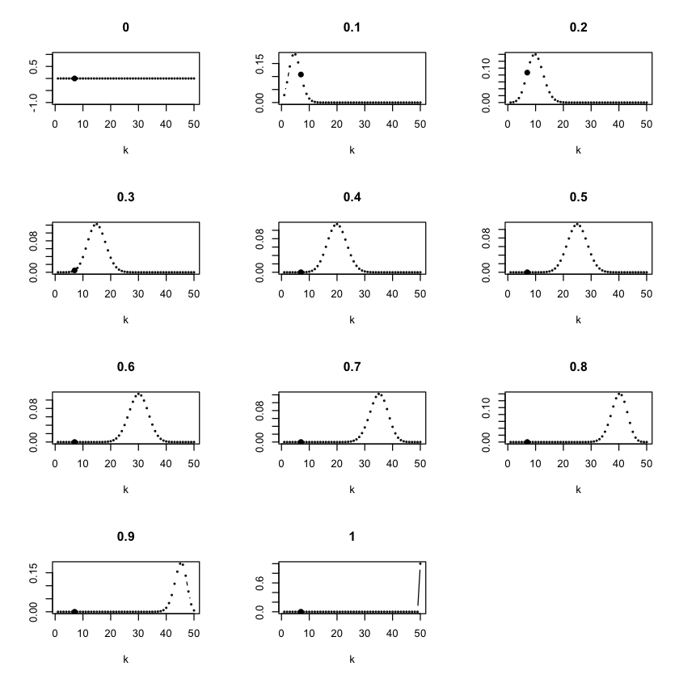

```r
layout(matrix(1:12,nrow=4,byrow=TRUE))
k <- seq(ssize)
pch <- rep(1,ssize)
pch[n_unemp] <- 16
cex <- rep(.3,ssize)
cex[n_unemp] <- 1.2
for(p in grid){
    plot(k,dbinom(k,ssize,p),type='b',pch=pch,cex=cex,ylab='',main=p)
}
layout(1)
```

### Back to calculating the posterior

Now that we have a prior and likelhood, we can just multiply them together and normalize them to get our posterior grid approximation:

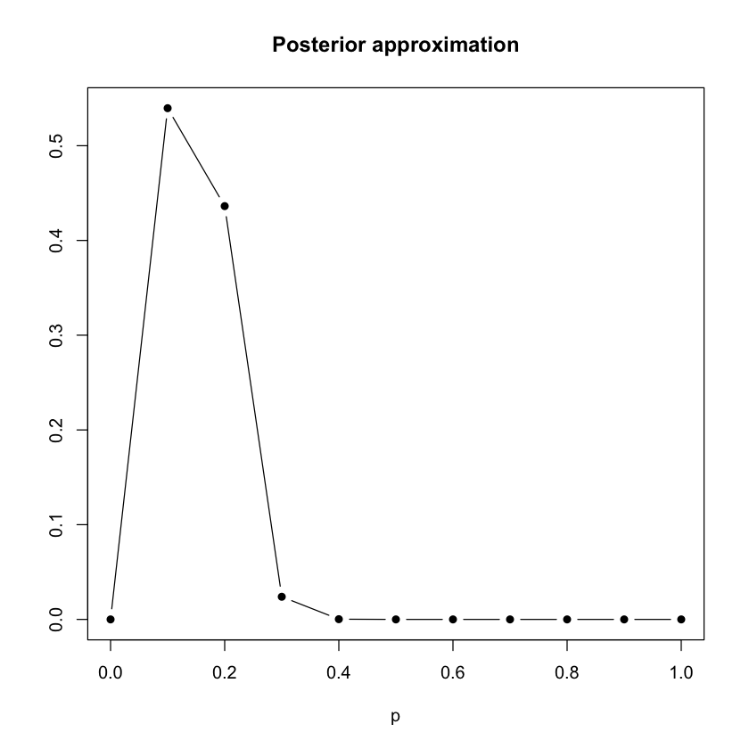

```r
posterior <- prior*lik
posterior <- posterior/sum(posterior)
plot(grid,posterior,type='b',pch=16,xlab='p',ylab='',main="Posterior approximation")
```

That looks accurate enough, but pretty sparse. Let's repeat all that but with `n_grid`=100.

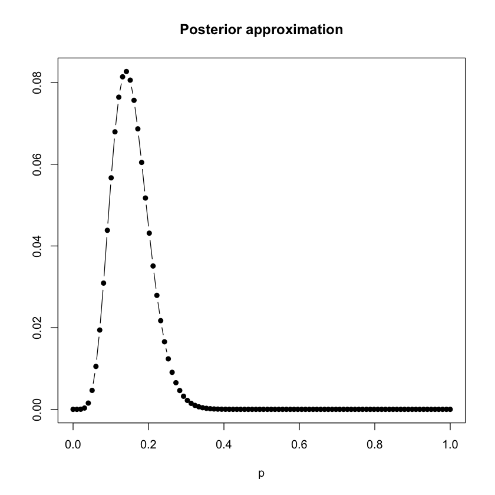

```r
n_grid <- 100
grid <- seq(from=0,to=1,length.out=n_grid)

prior <- rep(1,times=n_grid)

lik <- dbinom(n_unemp,size=ssize,prob=grid)

posterior <- prior*lik
posterior <- posterior/sum(posterior)
plot(grid,posterior,type='b',pch=16,xlab='p',ylab='',main="Posterior approximation")
```

## Playing with the prior

How does this change if we alter the prior probability for $p$?

First, let's pretend that we are absolutely certain that the unemployment rate is no higher than 20%, and we want to enforce that by building it into our model.

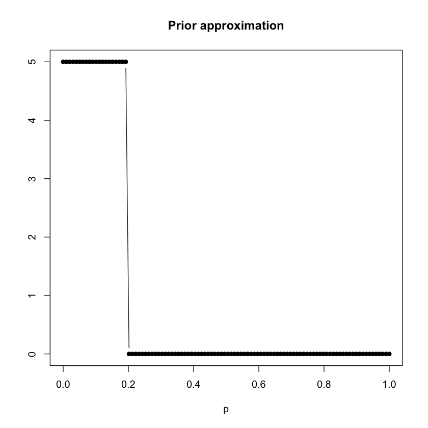

```r
# dunif() is like dbinom(), but for the uniform distribution rather than the binomial distribution
prior <- dunif(grid,min=0,max=0.2)
# plot that prior
plot(grid,prior,type='b',pch=16,xlab='p',ylab='',main="Prior approximation")
```

Apply that extreme prior to our data:

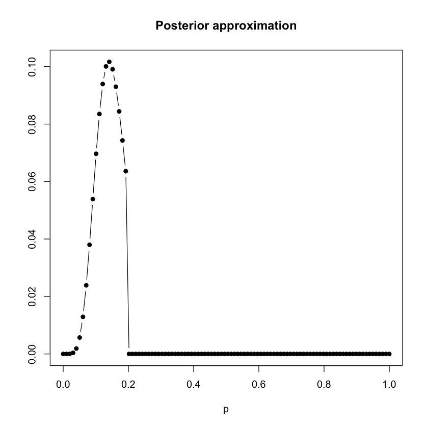

```r
lik <- dbinom(n_unemp,size=ssize,prob=grid)

posterior <- prior*lik
posterior <- posterior/sum(posterior)
plot(grid,posterior,type='b',pch=16,xlab='p',ylab='',main="Posterior approximation")
```

As one last example of an extreme prior, pretend we believe very deeply in our hearts that the true unemployment rate must be somewhere close to 100%. As very bad researchers, we could encode that belief into our model using a prior from a distribution called a 'beta' distribution. (The beta distribution with less extreme parameters is a very common prior for models like this).

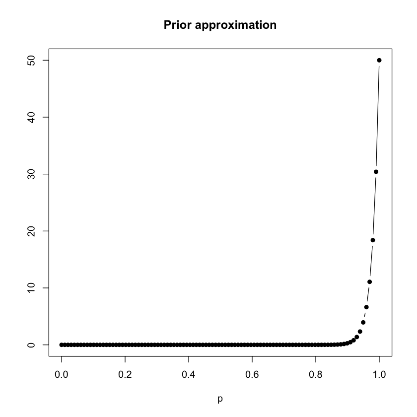

```r
prior <- dbeta(grid,50,1)

# plot the beta prior
plot(grid,prior,type='b',pch=16,xlab='p',ylab='',main="Prior approximation")
```

When we apply that prior, our model tries to take both the data and the unrealistic prior into account:

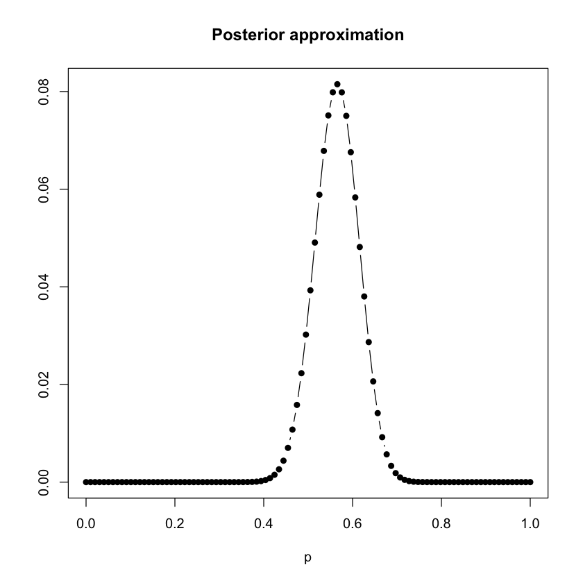

```r
lik <- dbinom(n_unemp,size=ssize,prob=grid)

posterior <- prior*lik
posterior <- posterior/sum(posterior)
plot(grid,posterior,type='b',pch=16,xlab='p',ylab='',main="Posterior approximation")
```